# Get started

This notebook contains the simple examples of time series forecasting pipeline using ETNA library.

**Table of Contents**

- Creating TSDataset
- Plotting
- Forecast single time series
  - Simple forecast
  - Prophet
  - Catboost
- Forecast multiple time series
- Pipeline

```python
import warnings

warnings.filterwarnings(action="ignore", message="Torchmetrics v0.9")
```

## 1. Creating TSDataset

Let's load and look at the dataset

```python
import pandas as pd
```

```python
original_df = pd.read_csv("data/monthly-australian-wine-sales.csv")
original_df.head()
```

|  | month | sales |
| --- | --- | --- |
| 0 | 1980-01-01 | 15136 |
| 1 | 1980-02-01 | 16733 |
| 2 | 1980-03-01 | 20016 |
| 3 | 1980-04-01 | 17708 |
| 4 | 1980-05-01 | 18019 |

etna_ts is strict about data format:

- column we want to predict should be called `target`
- column with datatime data should be called `timestamp`
- because etna is always ready to work with multiple time series, column `segment` is also compulsory

Our library works with the special data structure TSDataset. So, before starting anything, we need to convert the classical DataFrame to TSDataset.

Let's rename first

```python
original_df["timestamp"] = pd.to_datetime(original_df["month"])
original_df["target"] = original_df["sales"]
original_df.drop(columns=["month", "sales"], inplace=True)
original_df["segment"] = "main"
original_df.head()
```

|  | timestamp | target | segment |
| --- | --- | --- | --- |
| 0 | 1980-01-01 | 15136 | main |
| 1 | 1980-02-01 | 16733 | main |
| 2 | 1980-03-01 | 20016 | main |
| 3 | 1980-04-01 | 17708 | main |
| 4 | 1980-05-01 | 18019 | main |

Time to convert to TSDataset!

To do this, we initially need to convert the classical DataFrame to the special format.

```python
from etna.datasets.tsdataset import TSDataset
```

```python
df = TSDataset.to_dataset(original_df)
df.head()
```

| segment feature timestamp | main target |
| --- | --- |
| 1980-01-01 | 15136 |
| 1980-02-01 | 16733 |
| 1980-03-01 | 20016 |
| 1980-04-01 | 17708 |
| 1980-05-01 | 18019 |

Now we can construct the TSDataset.

Additionally to passing dataframe we should specify frequency of our data. In this case it is monthly data.

```python
ts = TSDataset(df, freq="1M")
```

```python
ts = TSDataset(df, freq="MS")
```

We can look at the basic information about the dataset

```python
ts.info()
```

```
<class 'etna.datasets.TSDataset'>
num_segments: 1
num_exogs: 0
num_regressors: 0
num_known_future: 0
freq: MS
         start_timestamp end_timestamp  length  num_missing
segments
main          1980-01-01    1994-08-01     176            0
```

Or in DataFrame format

```python
ts.describe()
```

| segments | start_timestamp | end_timestamp | length | num_missing | num_segments | num_exogs | num_regressors | num_known_future | freq |
| --- | --- | --- | --- | --- | --- | --- | --- | --- | --- |
| main | 1980-01-01 | 1994-08-01 | 176 | 0 | 1 | 0 | 0 | 0 | MS |

## 2. Plotting

Let's take a look at the time series in the dataset

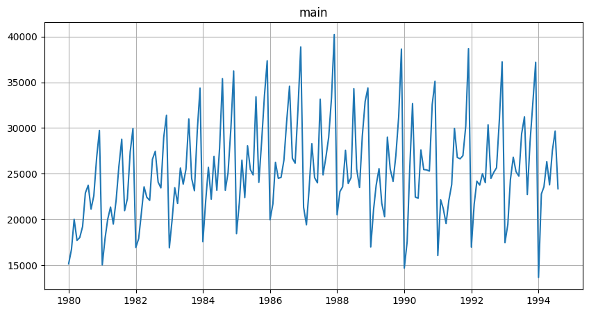

```python
ts.plot()
```

## 3. Forecasting single time series

Our library contains a wide range of different models for time series forecasting. Let's look at some of them.

### 3.1 Simple forecast

Let's predict the monthly values in 1994 in our dataset using the `NaiveModel`

```python
train_ts, test_ts = ts.train_test_split(
    train_start="1980-01-01",
    train_end="1993-12-01",
    test_start="1994-01-01",
    test_end="1994-08-01",
)
```

```python
HORIZON = 8
from etna.models import NaiveModel

# Fit the model
model = NaiveModel(lag=12)
model.fit(train_ts)

# Make the forecast
future_ts = train_ts.make_future(future_steps=HORIZON, tail_steps=model.context_size)
forecast_ts = model.forecast(future_ts, prediction_size=HORIZON)
```

Here we pass `prediction_size` parameter during `forecast` because in `forecast_ts` few first points are dedicated to be a context for `NaiveModel`.

Now let's look at a metric and plot the prediction. All the methods already built-in in etna.

```python
from etna.metrics import SMAPE
```

```python
smape = SMAPE()
smape(y_true=test_ts, y_pred=forecast_ts)
```

```
{'main': 11.492045838249387}
```

```python
from etna.analysis import plot_forecast
```

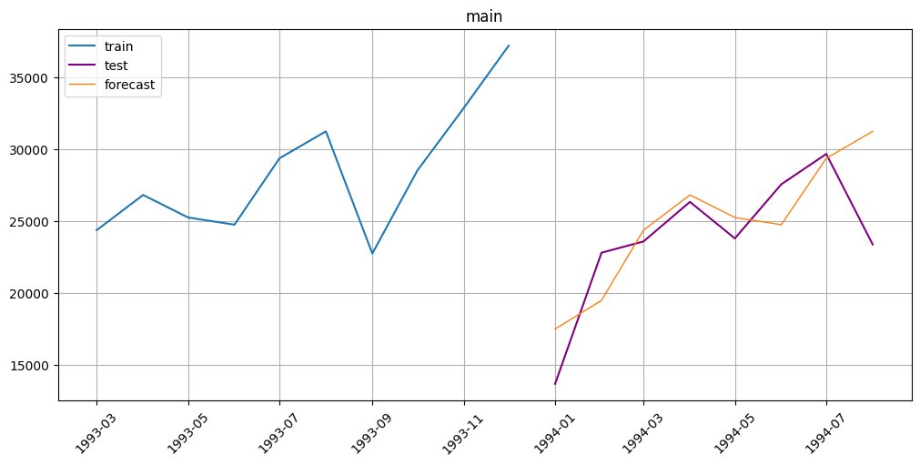

```python
plot_forecast(forecast_ts, test_ts, train_ts, n_train_samples=10)
```

### 3.2 Prophet

Now try to improve the forecast and predict the values with Prophet.

```python
from etna.models import ProphetModel

model = ProphetModel()
model.fit(train_ts)

# Make the forecast
future_ts = train_ts.make_future(HORIZON)
forecast_ts = model.forecast(future_ts)
```

```
11:41:24 - cmdstanpy - INFO - Chain [1] start processing
11:41:24 - cmdstanpy - INFO - Chain [1] done processing
```

```python
smape(y_true=test_ts, y_pred=forecast_ts)
```

```
{'main': 10.634152451904495}
```

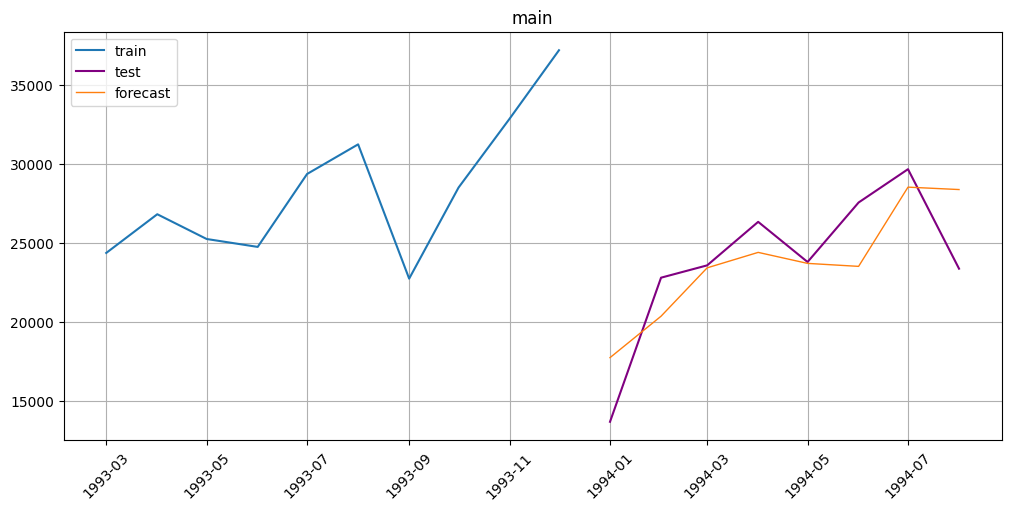

```python
plot_forecast(forecast_ts, test_ts, train_ts, n_train_samples=10)
```

### 3.2 Catboost

And finally let's try the Catboost model.

Also etna has wide range of transforms you may apply to your data.

Transforms are not stored in the dataset, so you should pass them explicitly to `transform`, `inverse_transform` and `make_future` methods.

Here how it is done:

```python
from etna.transforms import LagTransform, LogTransform

lags = LagTransform(in_column="target", lags=list(range(8, 24, 1)))
log = LogTransform(in_column="target")
transforms = [log, lags]
train_ts.fit_transform(transforms)
```

```python
from etna.models import CatBoostMultiSegmentModel

model = CatBoostMultiSegmentModel()
model.fit(train_ts)
future_ts = train_ts.make_future(future_steps=HORIZON, transforms=transforms)
forecast_ts = model.forecast(future_ts)
forecast_ts.inverse_transform(transforms)
```

```python
from etna.metrics import SMAPE

smape = SMAPE()
smape(y_true=test_ts, y_pred=forecast_ts)
```

```
{'main': 10.657026308972483}
```

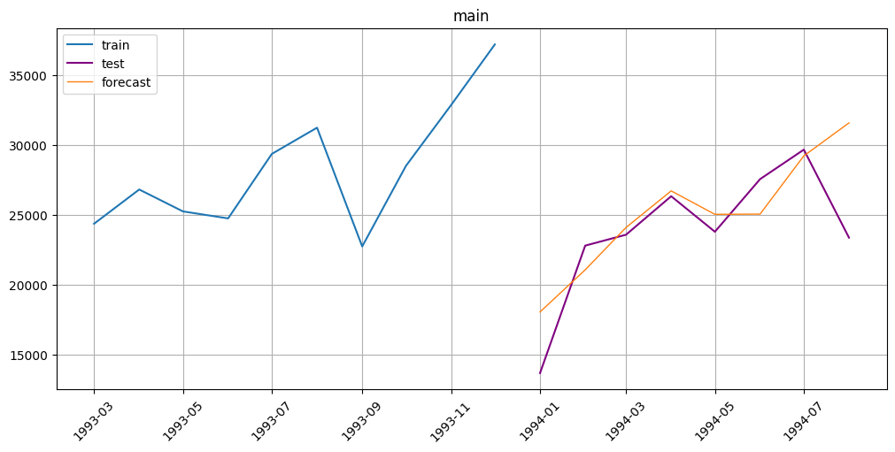

```python
from etna.analysis import plot_forecast

train_ts.inverse_transform(transforms)
plot_forecast(forecast_ts, test_ts, train_ts, n_train_samples=10)
```

## 4. Forecasting multiple time series

In this section you may see example of how easily etna works with multiple time series and get acquainted with other transforms etna contains.

```python
original_df = pd.read_csv("data/example_dataset.csv")
original_df.head()
```

|  | timestamp | segment | target |
| --- | --- | --- | --- |
| 0 | 2019-01-01 | segment_a | 170 |
| 1 | 2019-01-02 | segment_a | 243 |
| 2 | 2019-01-03 | segment_a | 267 |
| 3 | 2019-01-04 | segment_a | 287 |
| 4 | 2019-01-05 | segment_a | 279 |

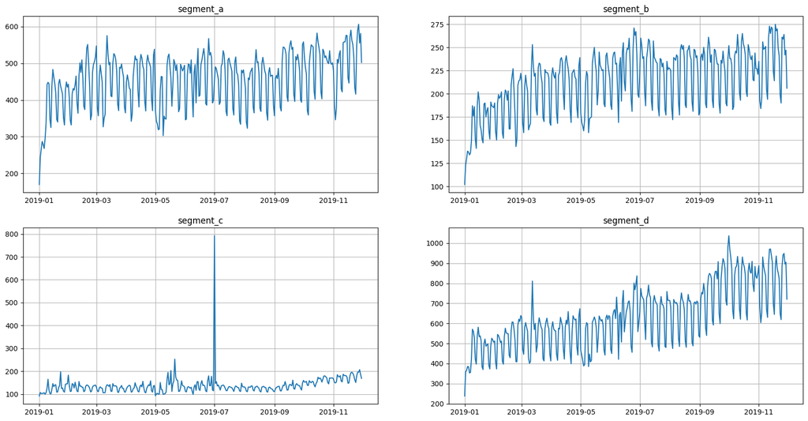

```python
df = TSDataset.to_dataset(original_df)
ts = TSDataset(df, freq="D")
ts.plot()
```

```python
ts.info()
```

```
<class 'etna.datasets.TSDataset'>
num_segments: 4
num_exogs: 0
num_regressors: 0
num_known_future: 0
freq: D
          start_timestamp end_timestamp  length  num_missing
segments
segment_a      2019-01-01    2019-11-30     334            0
segment_b      2019-01-01    2019-11-30     334            0
segment_c      2019-01-01    2019-11-30     334            0
segment_d      2019-01-01    2019-11-30     334            0
```

```python
import warnings

from etna.transforms import (
    MeanTransform,
    LagTransform,
    LogTransform,
    SegmentEncoderTransform,
    DateFlagsTransform,
    LinearTrendTransform,
)

warnings.filterwarnings("ignore")

log = LogTransform(in_column="target")
trend = LinearTrendTransform(in_column="target")
seg = SegmentEncoderTransform()

lags = LagTransform(in_column="target", lags=list(range(30, 96, 1)))
d_flags = DateFlagsTransform(
    day_number_in_week=True,
    day_number_in_month=True,
    week_number_in_month=True,
    week_number_in_year=True,
    month_number_in_year=True,
    year_number=True,
    special_days_in_week=[5, 6],
)
mean30 = MeanTransform(in_column="target", window=30)
transforms = [log, trend, lags, d_flags, seg, mean30]
```

```python
HORIZON = 30
train_ts, test_ts = ts.train_test_split(
    train_start="2019-01-01",
    train_end="2019-10-31",
    test_start="2019-11-01",
    test_end="2019-11-30",
)
train_ts.fit_transform(transforms)
```

```python
test_ts.info()
```

```
<class 'etna.datasets.TSDataset'>
num_segments: 4
num_exogs: 0
num_regressors: 0
num_known_future: 0
freq: D
          start_timestamp end_timestamp  length  num_missing
segments
segment_a      2019-11-01    2019-11-30      30            0
segment_b      2019-11-01    2019-11-30      30            0
segment_c      2019-11-01    2019-11-30      30            0
segment_d      2019-11-01    2019-11-30      30            0
```

```python
from etna.models.catboost import CatBoostMultiSegmentModel

model = CatBoostMultiSegmentModel()
model.fit(train_ts)
future_ts = train_ts.make_future(future_steps=HORIZON, transforms=transforms)
forecast_ts = model.forecast(future_ts)
forecast_ts.inverse_transform(transforms)
```

```python
smape = SMAPE()
smape(y_true=test_ts, y_pred=forecast_ts)
```

```
{'segment_a': 5.8968916688777995,
 'segment_b': 4.397964779952168,
 'segment_c': 10.435207629641658,
 'segment_d': 5.085585717990846}
```

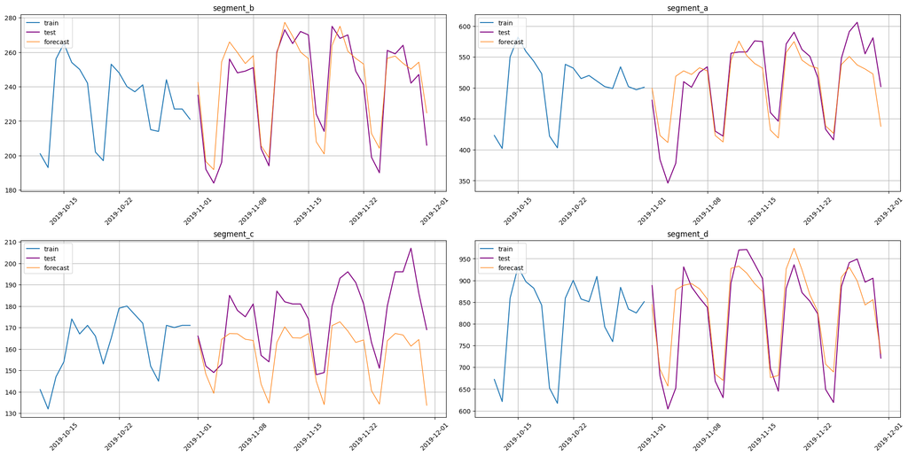

```python
train_ts.inverse_transform(transforms)
plot_forecast(forecast_ts, test_ts, train_ts, n_train_samples=20)
```

## 5. Pipeline

Let's wrap everything into pipeline to create the end-to-end model from previous section.

```python
from etna.pipeline import Pipeline
```

```python
train_ts, test_ts = ts.train_test_split(
    train_start="2019-01-01",
    train_end="2019-10-31",
    test_start="2019-11-01",
    test_end="2019-11-30",
)
```

We put: **model**, **transforms** and **horizon** in a single object, which has the similar interface with the model(fit/forecast)

```python
model = Pipeline(
    model=CatBoostMultiSegmentModel(),
    transforms=transforms,
    horizon=HORIZON,
)
model.fit(train_ts)
forecast_ts = model.forecast()
```

As in the previous section, let's calculate the metrics and plot the forecast

```python
smape = SMAPE()
smape(y_true=test_ts, y_pred=forecast_ts)
```

```
{'segment_a': 5.8968916688777995,
 'segment_b': 4.397964779952168,
 'segment_c': 10.435207629641658,
 'segment_d': 5.085585717990846}
```

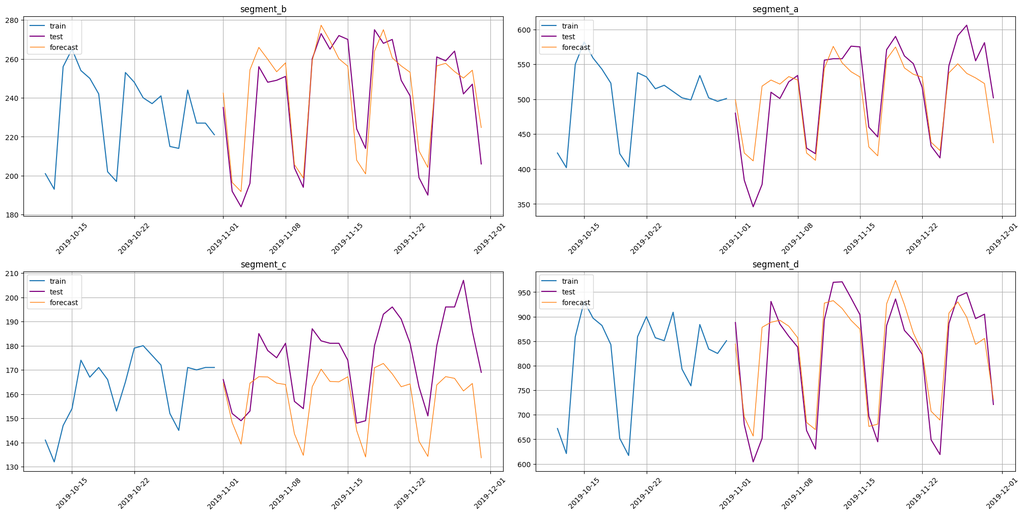

```python
plot_forecast(forecast_ts, test_ts, train_ts, n_train_samples=20)
```